# Model Evaluation

Sam Beighle

18 April, 2023

## Introduction

This assignment evaluates 5 different models estimating the price of subaru vehicles. This is the same data set that we worked on last week. This analysis will evaluate the models, and then pick the best ones and compare them on a few different metrics.

## Measures of Accuracy

The following code takes three measures of accuracy on each of the five models estimating the price of the subaru vehicle. The highest MAE value is 4111 from the fourth model, while the lowest is 1478 which is from the third model. The highest rmse is from the fourth model and the lowest is from the third model. The R^2 is also the same with the highest error coming from the fourth model and lowest from the third. The two lowest MAE values are from models 3 and 2 at 1478 and 1834, respectively. The lowest RMSE values are from models 3 and 2 at 2414 and 3041, respectively. Lastly, the highest R^2 values come from models 3 and 2 at 0.870 and 0.795, meaning that models 3 and 2 account for 87% and 79.5% of the variance in the actual price, respectively. In conclusion, models 2 and 3 are the best of the five models. Model 4 was the worst. The code also uses the mean percentage error (MPE) as a measure of accuracy. This calculates the mean percentage difference between the actual and predicted prices of that model. Interestingly, models 3 and 5 had the lowest MPE at -2341% and -2232%, respectively. This is quite a large difference in the average percentage of the actual and predicted values. Overall, the measures of accuracy show that the models are not great predictors of the price, but models 2 and 3 are still the best.

```r
# Model 1

training_price_estimates <- read.table("training_price_estimates.txt", header = TRUE, sep = "\t")

predictedvalues1 <- training_price_estimates$model1_est

# Calculate RMSE
rmse1 <- sqrt(mean((training_price_estimates$price - predictedvalues1)^2, na.rm = TRUE))
cat("RMSE:", rmse1, "\n")
```

```
## RMSE: 3475.651
```

```r
mae1 <- mean(abs(training_price_estimates$price - training_price_estimates$model1_est), na.rm = TRUE)
cat("MAE:", mae1, "\n")
```

```
## MAE: 2333.013
```

```r
# Calculate R-squared

train.lm <- lm(price ~ model1_est, data = training_price_estimates)

r_squared1 <- summary(train.lm)$r.squared

cat("R-squared:", r_squared1, "\n")
```

```
## R-squared: 0.7288617
```

```r
# Calculate MPE
mpe1 <- mean((training_price_estimates$price - training_price_estimates$model1_est) / training_price_estimates$price, na.rm = TRUE) * 100
cat("MPE:", mpe1, "%\n")
```

```
## MPE: -2985.74 %
```

```r
# Model 2


# Calculate RMSE
rmse2 <- sqrt(mean((training_price_estimates$price - training_price_estimates$model2_est)^2, na.rm = TRUE))
cat("RMSE:", rmse2, "\n")
```

```
## RMSE: 3041.704
```

```r
mae2 <- mean(abs(training_price_estimates$price - training_price_estimates$model2_est), na.rm = TRUE)
cat("MAE:", mae2, "\n")
```

```
## MAE: 1834.717
```

```r
# Calculate R-squared

train.lm <- lm(price ~ model2_est, data = training_price_estimates)

r_squared2 <- summary(train.lm)$r.squared

cat("R-squared:", r_squared2, "\n")
```

```
## R-squared: 0.7948002
```

```r
# Calculate MPE
mpe2 <- mean((training_price_estimates$price - training_price_estimates$model2_est) / training_price_estimates$price, na.rm = TRUE) * 100
cat("MPE:", mpe2, "%\n")
```

```
## MPE: -2433.723 %
```

```r
# Model 3


# Calculate RMSE
rmse3 <- sqrt(mean((training_price_estimates$price - training_price_estimates$model3_est)^2, na.rm = TRUE))
cat("RMSE:", rmse3, "\n")
```

```
## RMSE: 2415
```

```r
mae3 <- mean(abs(training_price_estimates$price - training_price_estimates$model3_est), na.rm = TRUE)
cat("MAE:", mae3, "\n")
```

```
## MAE: 1478.307
```

```r
# Calculate R-squared

train.lm <- lm(price ~ model3_est, data = training_price_estimates)

r_squared3 <- summary(train.lm)$r.squared

cat("R-squared:", r_squared3, "\n")
```

```
## R-squared: 0.8704136
```

```r
# Calculate MPE
mpe3 <- mean((training_price_estimates$price - training_price_estimates$model3_est) / training_price_estimates$price, na.rm = TRUE) * 100
cat("MPE:", mpe3, "%\n")
```

```
## MPE: -2341.366 %
```

```r
# Model 4


# Calculate RMSE
rmse4 <- sqrt(mean((training_price_estimates$price - training_price_estimates$model4_est)^2, na.rm = TRUE))
cat("RMSE:", rmse4, "\n")
```

```
## RMSE: 5500.806
```

```r
mae4 <- mean(abs(training_price_estimates$price - training_price_estimates$model4_est), na.rm = TRUE)
cat("MAE:", mae4, "\n")
```

```
## MAE: 4111.327
```

```r
# Calculate R-squared

train.lm <- lm(price ~ model4_est, data = training_price_estimates)

r_squared4 <- summary(train.lm)$r.squared

cat("R-squared:", r_squared4, "\n")
```

```
## R-squared: 0.3315361
```

```r
# Calculate MPE
mpe4 <- mean((training_price_estimates$price - training_price_estimates$model4_est) / training_price_estimates$price, na.rm = TRUE) * 100
cat("MPE:", mpe4, "%\n")
```

```
## MPE: -3345.624 %
```

```r
# Model 5


# Calculate RMSE
rmse5 <- sqrt(mean((training_price_estimates$price - training_price_estimates$model5_est)^2, na.rm = TRUE))
cat("RMSE:", rmse5, "\n")
```

```
## RMSE: 3690.055
```

```r
mae5 <- mean(abs(training_price_estimates$price - training_price_estimates$model5_est), na.rm = TRUE)
cat("MAE:", mae5, "\n")
```

```
## MAE: 2412.584
```

```r
# Calculate R-squared

train.lm <- lm(price ~ model5_est, data = training_price_estimates)

r_squared5 <- summary(train.lm)$r.squared

cat("R-squared:", r_squared5, "\n")
```

```
## R-squared: 0.6936949
```

```r
# Calculate MPE
mpe5 <- mean((training_price_estimates$price - training_price_estimates$model5_est) / training_price_estimates$price, na.rm = TRUE) * 100
cat("MPE:", mpe5, "%\n")
```

```
## MPE: -2232.293 %
```

## Best Models: 2 & 3

The first step in evaluating the top 2 models is to see how they perform across car models. The smallest RMSE values are in the impreza and legacy estimates. The smallest MAE values are also seen in the impreza and legacy models. However, model 3 is the most accurate for the impreza and forester models. Both of the plots display similar linear relationships across the models when compared to the actual values.

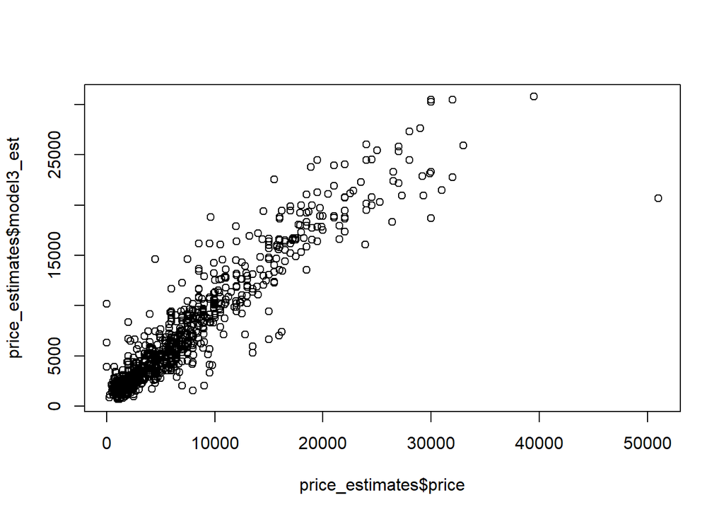

```r
#Car Models

price_estimates <- read.table("price_estimates.txt", header = TRUE, sep = "\t")

# Plot the residuals of each model by car model
plot(price_estimates$price, price_estimates$model3_est)
```

```r
library(dplyr)

#Model 2
performance_by_model2 <- price_estimates %>%
  group_by(model) %>%
  summarise(RMSE = sqrt(mean((price - model2_est)^2, na.rm = TRUE)),
            MAE = mean(abs(price - model2_est), na.rm = TRUE))

print(performance_by_model2)
```

```
## # A tibble: 10 × 3
##    model           RMSE   MAE
##    <chr>          <dbl> <dbl>
##  1 brz            2774. 2108.
##  2 forester       2186. 1537.
##  3 forester-xt    6482. 3324.
##  4 impreza        1680. 1334.
##  5 impreza-wrx    2207. 1708.
##  6 legacy         2155. 1442.
##  7 legacy-outback 2186. 1695
##  8 outback        2720. 1835.
##  9 sti-wrx        7735. 4582.
## 10 wrx            3077. 2216.
```

```r
#Model 3
performance_by_model3 <- price_estimates %>%
  group_by(model) %>%
  summarise(RMSE = sqrt(mean((price - model3_est)^2, na.rm = TRUE)),
            MAE = mean(abs(price - model3_est), na.rm = TRUE))

print(performance_by_model3)
```

```
## # A tibble: 10 × 3
##    model           RMSE   MAE
##    <chr>          <dbl> <dbl>
##  1 brz            2642. 1919.
##  2 forester       1733. 1166.
##  3 forester-xt    2830. 1790.
##  4 impreza        1497. 1151.
##  5 impreza-wrx    2172. 1755.
##  6 legacy         1925. 1252.
##  7 legacy-outback 1768. 1237.
##  8 outback        2136. 1407.
##  9 sti-wrx        6949. 4194.
## 10 wrx            2806. 1957.
```

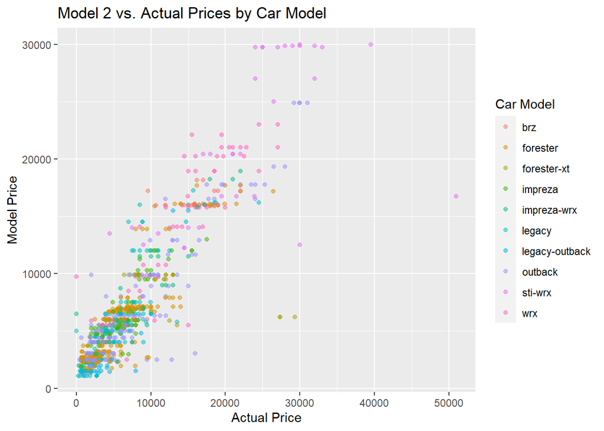

```r
car.model <- price_estimates %>%
  select(model, price, model2_est)

ggplot(car.model, aes(x = price, y = model2_est, color = model)) +
  geom_point(alpha = 0.5) +
  labs(x = "Actual Price", y = "Model Price", color = "Car Model") +
  ggtitle("Model 2 vs. Actual Prices by Car Model")
```

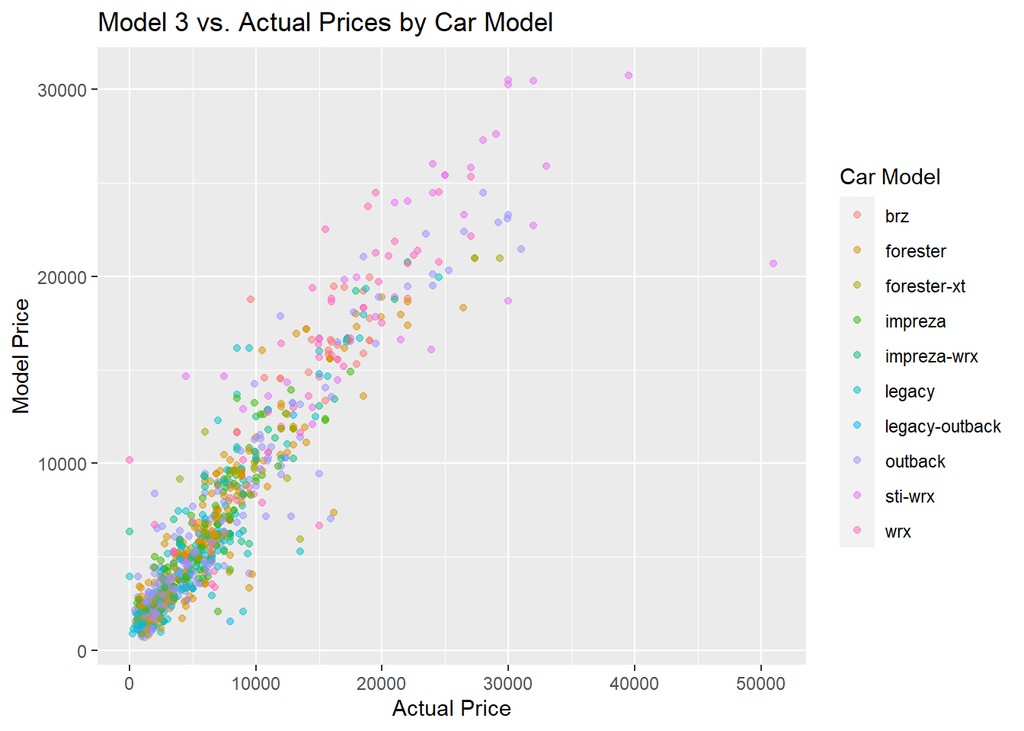

```r
car.model <- price_estimates %>%
  select(model, price, model3_est)

ggplot(car.model, aes(x = price, y = model3_est, color = model)) +
  geom_point(alpha = 0.5) +
  labs(x = "Actual Price", y = "Model Price", color = "Car Model") +
  ggtitle("Model 3 vs. Actual Prices by Car Model")
```

```r
#Years

#Model 2
performance_by_model2 <- price_estimates %>%
  group_by(year) %>%
  summarise(RMSE = sqrt(mean((price - model2_est)^2, na.rm = TRUE)),
            MAE = mean(abs(price - model2_est), na.rm = TRUE))

print(performance_by_model2)
```

```
## # A tibble: 25 × 3
##     year  RMSE   MAE
##    <int> <dbl> <dbl>
##  1  1993 1116. 1100
##  2  1994  400   400
##  3  1995 1003.  796.
##  4  1996  814.  671.
##  5  1997  817.  645.
##  6  1998 1871.  978.
##  7  1999 1425. 1034.
##  8  2000 3124. 2058.
##  9  2001 1218.  988.
## 10  2002 5149. 2494.
## # ℹ 15 more rows
```

```r
#Model 3
performance_by_model3 <- price_estimates %>%
  group_by(year) %>%
  summarise(RMSE = sqrt(mean((price - model3_est)^2, na.rm = TRUE)),
            MAE = mean(abs(price - model3_est), na.rm = TRUE))

print(performance_by_model3)
```

```
## # A tibble: 25 × 3
##     year  RMSE   MAE
##    <int> <dbl> <dbl>
##  1  1993 1702. 1649.
##  2  1994  310.  310.
##  3  1995  859.  776.
##  4  1996 1455.  939.
##  5  1997  698.  563.
##  6  1998 1819. 1054.
##  7  1999  856.  686.
##  8  2000 2443. 1582.
##  9  2001 1023.  697.
## 10  2002 2375. 1576.
## # ℹ 15 more rows
```

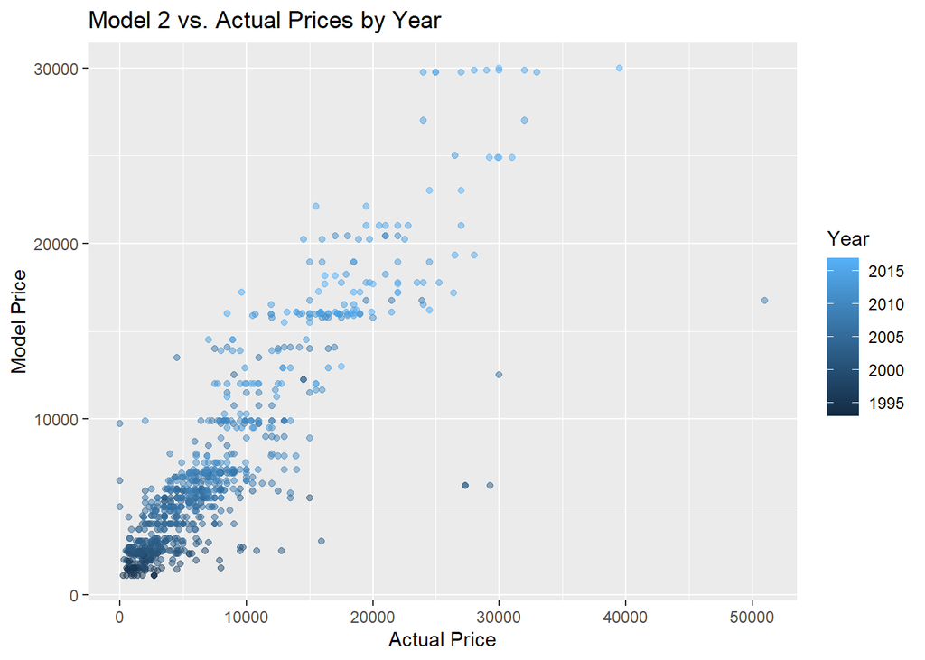

```r
year.model <- price_estimates %>%
  select(year, price, model2_est)

ggplot(year.model, aes(x = price, y = model2_est, color = year)) +
  geom_point(alpha = 0.5) +
  labs(x = "Actual Price", y = "Model Price", color = "Year") +
  ggtitle("Model 2 vs. Actual Prices by Year")
```

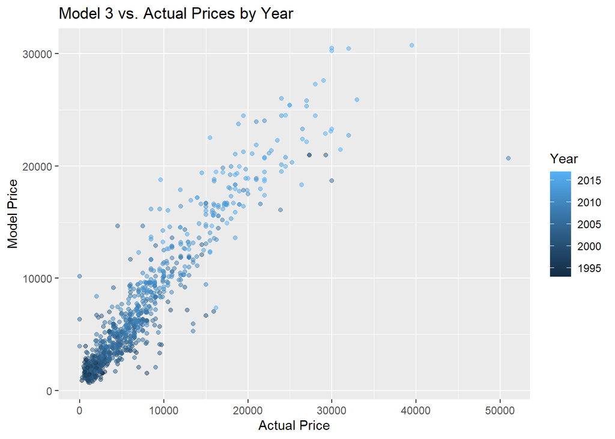

```r
year.model <- price_estimates %>%
  select(year, price, model3_est)

ggplot(year.model, aes(x = price, y = model3_est, color = year)) +
  geom_point(alpha = 0.5) +
  labs(x = "Actual Price", y = "Model Price", color = "Year") +
  ggtitle("Model 3 vs. Actual Prices by Year")
```

The final step in evaluating the top 2 models is to see how they perform across the odometer readings. The tables created showing the odometer readings is difficult because it shows it across every reading. Therefore, this section will use the plots below. There is much more variability in the 2nd model across the odometer compared to the 3rd model. We can see this by the points being closer together and showing a stronger linear relationship in model 3. They both have outliers. Lastly, both have much stronger correlation in the lower price values. As the values get larger, the less data points and the more variability.

```r
#Model 3
performance_by_model2 <- price_estimates %>%
  group_by(odometer) %>%
  summarise(RMSE = sqrt(mean((price - model2_est)^2, na.rm = TRUE)),
            MAE = mean(abs(price - model2_est), na.rm = TRUE))

print(performance_by_model2)
```

```
## # A tibble: 526 × 3
##    odometer  RMSE   MAE
##       <int> <dbl> <dbl>
##  1       10 1500  1500
##  2       89 2000  2000
##  3      120 4999  4999
##  4      126 1251  1251
##  5      129  910   910
##  6      133  403.  350
##  7      145 4050. 4050.
##  8      146 2799  2799
##  9      147 3249. 3247
## 10      154 2198  2198
## # ℹ 516 more rows
```

```r
#Model 3
performance_by_model3 <- price_estimates %>%
  group_by(odometer) %>%
  summarise(RMSE = sqrt(mean((price - model3_est)^2, na.rm = TRUE)),
            MAE = mean(abs(price - model3_est), na.rm = TRUE))

print(performance_by_model3)
```

```
## # A tibble: 526 × 3
##    odometer   RMSE    MAE
##       <int>  <dbl>  <dbl>
##  1       10 8820.  8820.
##  2       89 3089.  3089.
##  3      120 3942.  3942.
##  4      126 1055.  1055.
##  5      129   47.8   47.8
##  6      133  999.   972.
##  7      145 2464.  2464.
##  8      146 1902.  1902.
##  9      147 2033.  2031.
## 10      154 1241.  1241.
## # ℹ 516 more rows
```

```r
odometer.comb <- cbind(performance_by_model2, performance_by_model3, ncol = 2)

print(odometer.comb)
```

[output not shown]

[output cut: 512 more lines]

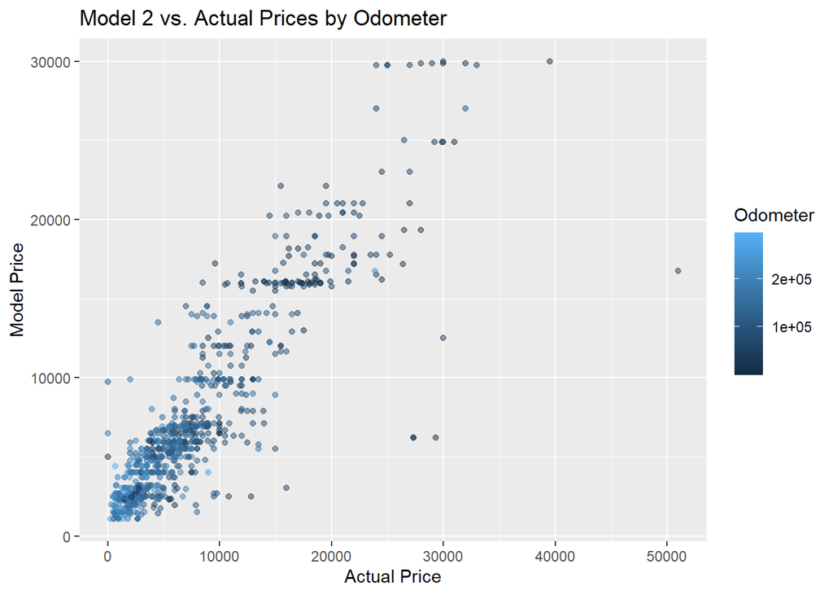

```r
odometer.model <- price_estimates %>%
  select(odometer, price, model2_est)

ggplot(odometer.model, aes(x = price, y = model2_est, color = odometer)) +
  geom_point(alpha = 0.5) +
  labs(x = "Actual Price", y = "Model Price", color = "Odometer") +
  ggtitle("Model 2 vs. Actual Prices by Odometer")
```

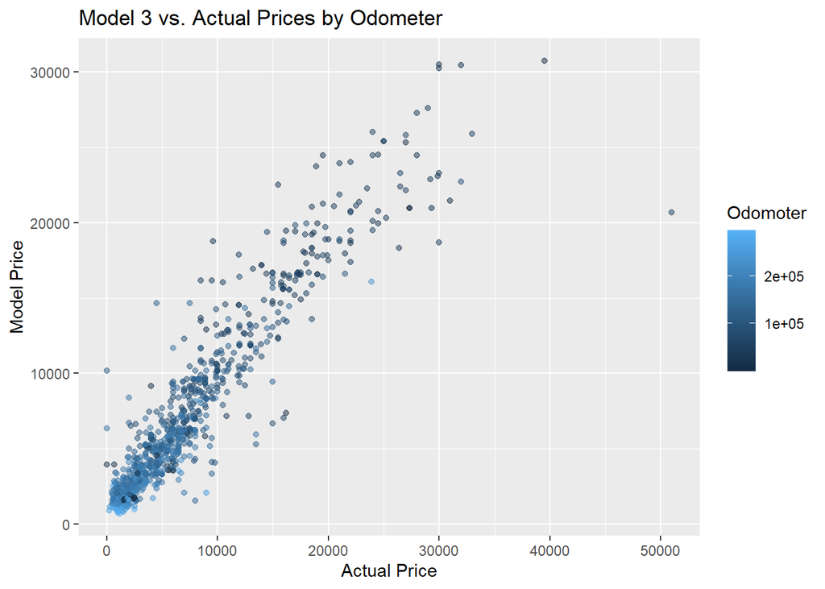

```r
year.model <- price_estimates %>%
  select(odometer, price, model3_est)

ggplot(year.model, aes(x = price, y = model3_est, color = odometer)) +
  geom_point(alpha = 0.5) +
  labs(x = "Actual Price", y = "Model Price", color = "Odomoter") +
  ggtitle("Model 3 vs. Actual Prices by Odometer")
```

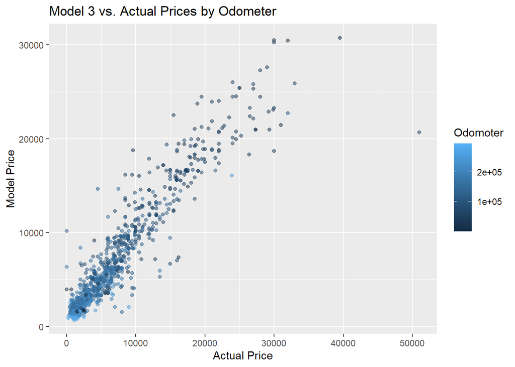

```r
par(mfrow=c(1,2))
odometer.model <- price_estimates %>%
  select(odometer, price, model2_est)
plot1 <- ggplot(odometer.model, aes(x = price, y = model2_est, color = odometer)) +
  geom_point(alpha = 0.5) +
  labs(x = "Actual Price", y = "Model Price", color = "Odometer") +
  ggtitle("Model 2 vs. Actual Prices by Odometer")


year.model <- price_estimates %>%
  select(odometer, price, model3_est)
plot2 <- ggplot(year.model, aes(x = price, y = model3_est, color = odometer)) +
  geom_point(alpha = 0.5) +
  labs(x = "Actual Price", y = "Model Price", color = "Odomoter") +
  ggtitle("Model 3 vs. Actual Prices by Odometer")

# Show the plots side by side
par(mfrow=c(1,2))
plot2
```